# Predicting the Prices of Sneakers in the Secondary Resale Market

### By Tony Truong

[figure not shown]

## Introduction

Welcome to my Data Science Tutorial. I will be walking through the Data Science pipeline which consists of five phases in the order of data collection/curation and parsing, data management/representation, exploratory data analysis, hypothesis testing and machine learning, and communication of insights attained.

The context of the data that I will be using is of the market of sneakers. Hundreds of millions of dollars are spent in the research and development of sneakers. The sneaker culture started in 1984 with Air Jordan, a line of sneakers made by Michael Jordan and Nike. Today, athletes and celebrities collaborate with sneaker companies like Nike and Adidas to create sneakers that ethusiasts are willing to camp out hours to obtain. Air Jordans are still one of the best selling sneakers, selling out within seconds online. According to Statista, the total global sneakers market was valued at approximately 79 billion U.S. dollars. This market's growth is increasing quickly and is forcasted to reach 119.5 billion U.S. dollars by 2026. That is not all of it either. In 2019, the global secondary sneaker resale market stood at 6 billion U.S. dollars and is expected to reach 30 billion U.S. dollars by 2030 according to Cowen, a market research firm. There is a lot of money to be made in the sneaker resale market. There are many who make hundreds of thousands of dollars buying sneakers at retail and reselling them. There are also many individuals who invest in bulk pairs of sneakers from the secondary market and holds them until the price rises, similar to the stock market in a way.

In 2016, a startup company name Stockx was launched. It is based in Detriot, Michigan and now has locations around the world. As of April 2021, Stockx as a company was valued at 3.8 billion U.S. dollars. Stockx is an online marketplace where consumers can place bids and sellers can place asks. When a bid and ask meet, the transaction happens automatically and the seller ships the item to Stockx for them to check the authenticity and condition of the item before shipping the item to the buyer. These sales are going to make up the data that we are going to be using in this tutorial.

## Getting Started

First of all, we will need to import the appropriate Python libraries that we will be using for data collection and for plotting the data that we collect. We will be importing the requests library to send GET requests to the StockX API to access the data. Further detailed usage of the requests library can be found in the [Python requests documentation](https://pypi.org/project/requests/). Next, we will be importing the json library because when we use the StockX API, we get json data as responses so we need the json library to be able to easily decode the jsons. Further detailed usage of the json library can be found in the [Python json documentation](https://docs.python.org/3/library/json.html). Next, we need a structure for retaining and manipulating the data that we collect. This where pandas comes into play. Further detailed usage of the pandas can be found in the [pandas documentation](https://pandas.pydata.org/docs/). Then, we need a library that will be able to plot the data for visualization. This is what we will be importing pyplot from matplotlib for. Further detailed usage of pyplot can be found in the [pyplot documentation](https://matplotlib.org/stable/api/pyplot_summary.html). Next, we will need to import datetime to convert our data to a type we can use for machine learning. Then, we are going to import linear_model from sklearn so that we can fit a linear model on our data. Further detailed usage of linear_model can be found [here](https://scikit-learn.org/stable/modules/classes.html#module-sklearn.linear_model).

```python
import requests as req
import json
import pandas as pd
import matplotlib.pyplot as plt
import datetime as dt
from sklearn import linear_model
```

## Data Collection

One of the ways that we can collect data from [StockX](https://stockx.com) is through web scraping. To start off, we have to figure out how to use StockX's API. They do not have official documentation for their API so we will have to do some digging for ourselves.

1. Go to any product page on Stockx

[figure not shown]

2. Open Chrome's Developer Tools using F12
3. Go to the network tab

[figure not shown]

4. Click "View All Sales" on the product page

[figure not shown]

5. Observe the network log for the stockx api request

[figure not shown]

```python
url = 'https://stockx.com/api/products/28aff902-d9a8-4dfa-b6b8-12d2971eefcb/activity?state=480&currency=USD&limit=10000&page=1&sort=createdAt&order=DESC&country=US'
headers = {'user-agent': 'Mozilla/5.0 (Windows NT 10.0; Win64; x64) AppleWebKit/537.36 (KHTML, like Gecko) Chrome/81.0.4044.138 Safari/537.36'}
r = req.get(url, headers=headers)
json_data = json.loads(r.text)

df = pd.DataFrame(json_data["ProductActivity"])
df.head()
```

|  | chainId | amount | createdAt | shoeSize | productId | skuUuid | state | customerId | localAmount | localCurrency |
| --- | --- | --- | --- | --- | --- | --- | --- | --- | --- | --- |
| 0 | 13600282442446527404 | 404.0000 | 2021-05-17T19:45:33+00:00 | 11.5 | None | d6ca0a33-3630-4531-a7d6-76fb1eb06638 | 480 | None | 404 | USD |
| 1 | 13600286702261583078 | 350.0000 | 2021-05-17T19:42:01+00:00 | 10 | None | 3ee64569-d1a6-459a-b36f-16d09dfdb89b | 480 | None | 350 | USD |
| 2 | 13599938927100023965 | 363.0000 | 2021-05-17T19:41:10+00:00 | 9 | None | ac194d48-c68b-4bc3-8a17-a426a09bd2ca | 480 | None | 363 | USD |
| 3 | 13599454344445593220 | 418.1379 | 2021-05-17T19:40:23+00:00 | 9.5 | None | 35c68973-cc88-4d27-bb18-d14d59f4a51c | 480 | None | 419 | USD |
| 4 | 13600284625804086366 | 351.0000 | 2021-05-17T19:37:58+00:00 | 10 | None | 3ee64569-d1a6-459a-b36f-16d09dfdb89b | 480 | None | 351 | USD |

This data frame gives us the details for the last 250 sales for the Jordan 1 Retro High OG Hyper Royal. We can repeat these steps for any sneaker/product that we want to collect data for. The problem with this data is that it is very messy. There are a lot of data that we do not need that is a part of it and we also have to do this manually for each and every shoe that we want to analyze. It will be very repetitive.

What we can do is use a dataset that StockX provided in 2019 for a data contest. The data consists of a random sample of all Off-White x Nike and Yeezy 350 sales from between 9/1/2017 to 2/13/2019. It consist of a total of 99,956 sales from the U.S. only. 27,794 of the sales were Off-White sales and 72,162 of the sales were Yeezy sales. More information of the data and the contest that StockX held can be found [here](https://stockx.com/news/the-2019-data-contest/) and the link to download the data can be found [here](https://s3.amazonaws.com/stockx-sneaker-analysis/wp-content/uploads/2019/02/StockX-Data-Contest-2019-3.xlsx). Since the data is in an excel sheet, we can use pandas read_excel() function to read the data into a pandas dataframe. We will pass in the path of the data as a string.

```python
df = pd.read_excel('StockX-Data-Contest-2019-3.xlsx')
df.head()
```

|  | Order Date | Brand | Sneaker Name | Sale Price | Retail Price | Release Date | Shoe Size | Buyer Region |
| --- | --- | --- | --- | --- | --- | --- | --- | --- |
| 0 | 2017-09-01 | Yeezy | Adidas-Yeezy-Boost-350-Low-V2-Beluga | 1097.0 | 220 | 2016-09-24 | 11.0 | California |
| 1 | 2017-09-01 | Yeezy | Adidas-Yeezy-Boost-350-V2-Core-Black-Copper | 685.0 | 220 | 2016-11-23 | 11.0 | California |
| 2 | 2017-09-01 | Yeezy | Adidas-Yeezy-Boost-350-V2-Core-Black-Green | 690.0 | 220 | 2016-11-23 | 11.0 | California |
| 3 | 2017-09-01 | Yeezy | Adidas-Yeezy-Boost-350-V2-Core-Black-Red | 1075.0 | 220 | 2016-11-23 | 11.5 | Kentucky |
| 4 | 2017-09-01 | Yeezy | Adidas-Yeezy-Boost-350-V2-Core-Black-Red-2017 | 828.0 | 220 | 2017-02-11 | 11.0 | Rhode Island |

Now that we have the data in a data frame, we can start tidying it up. We need to clean the data up as there are variables that we will not be using at all, possibly data types that we cannot use, and it makes for a cleaner attempt at plotting the data.

## Tidying the Data

First off, we can separate the data into two different data frames by brand. We can do this by using the pandas function pandas.DataFrame.loc which accesses a group of rows and columns by label(s) or a boolean array.

```python
offwhite_df = df.loc[df['Brand'] == "Off-White"]
offwhite_df.head()
```

|  | Order Date | Brand | Sneaker Name | Sale Price | Retail Price | Release Date | Shoe Size | Buyer Region |
| --- | --- | --- | --- | --- | --- | --- | --- | --- |
| 128 | 2017-09-07 | Off-White | Nike-Air-Max-90-Off-White | 1600.0 | 160 | 2017-09-09 | 8.0 | California |
| 129 | 2017-09-07 | Off-White | Nike-Air-Max-90-Off-White | 1090.0 | 160 | 2017-09-09 | 11.5 | New York |
| 130 | 2017-09-07 | Off-White | Nike-Air-Presto-Off-White | 1344.0 | 160 | 2017-09-09 | 10.0 | New York |
| 131 | 2017-09-07 | Off-White | Nike-Air-Presto-Off-White | 1325.0 | 160 | 2017-09-09 | 10.0 | Massachusetts |
| 132 | 2017-09-07 | Off-White | Nike-Air-VaporMax-Off-White | 1800.0 | 250 | 2017-09-09 | 12.0 | Kentucky |

```python
yeezy_df = df.loc[df['Brand'] == ' Yeezy']
yeezy_df.head()
```

|  | Order Date | Brand | Sneaker Name | Sale Price | Retail Price | Release Date | Shoe Size | Buyer Region |
| --- | --- | --- | --- | --- | --- | --- | --- | --- |
| 0 | 2017-09-01 | Yeezy | Adidas-Yeezy-Boost-350-Low-V2-Beluga | 1097.0 | 220 | 2016-09-24 | 11.0 | California |
| 1 | 2017-09-01 | Yeezy | Adidas-Yeezy-Boost-350-V2-Core-Black-Copper | 685.0 | 220 | 2016-11-23 | 11.0 | California |
| 2 | 2017-09-01 | Yeezy | Adidas-Yeezy-Boost-350-V2-Core-Black-Green | 690.0 | 220 | 2016-11-23 | 11.0 | California |
| 3 | 2017-09-01 | Yeezy | Adidas-Yeezy-Boost-350-V2-Core-Black-Red | 1075.0 | 220 | 2016-11-23 | 11.5 | Kentucky |
| 4 | 2017-09-01 | Yeezy | Adidas-Yeezy-Boost-350-V2-Core-Black-Red-2017 | 828.0 | 220 | 2017-02-11 | 11.0 | Rhode Island |

Now that we have separated the two brands into different data frames, we can start cleaning working on each one. For our analysis, we will not need the brand, retail price, release date, shoe size, or buyer region. We can drop those columns using the pandas.DataFrame.drop function. We pass a string containing the name of the column that we want to drop and a 0 or 1 depending on the axis that we want to drop. 0 for rows and 1 for columns. In our case, we will be passing in a 1 to delete columns. Since we can't use datetime objects for linear regression. We have to convert our Order Date to toordinal.

```python
offwhite_df = offwhite_df.drop('Brand', 1)
offwhite_df = offwhite_df.drop('Retail Price', 1)
offwhite_df = offwhite_df.drop('Release Date', 1)
offwhite_df = offwhite_df.drop('Shoe Size', 1)
offwhite_df = offwhite_df.drop('Buyer Region', 1)
offwhite_df = offwhite_df.reset_index(drop=True)
offwhite_df["Order Date"] = pd.to_datetime(offwhite_df["Order Date"])
offwhite_df["Order Date"]= offwhite_df["Order Date"].map(dt.datetime.toordinal)
offwhite_df.head()
```

|  | Order Date | Sneaker Name | Sale Price |
| --- | --- | --- | --- |
| 0 | 736579 | Nike-Air-Max-90-Off-White | 1600.0 |
| 1 | 736579 | Nike-Air-Max-90-Off-White | 1090.0 |
| 2 | 736579 | Nike-Air-Presto-Off-White | 1344.0 |
| 3 | 736579 | Nike-Air-Presto-Off-White | 1325.0 |
| 4 | 736579 | Nike-Air-VaporMax-Off-White | 1800.0 |

```python
yeezy_df = yeezy_df.drop('Brand', 1)
yeezy_df = yeezy_df.drop('Retail Price', 1)
yeezy_df = yeezy_df.drop('Release Date', 1)
yeezy_df = yeezy_df.drop('Shoe Size', 1)
yeezy_df = yeezy_df.drop('Buyer Region', 1)
yeezy_df = yeezy_df.reset_index(drop=True)
yeezy_df["Order Date"] = pd.to_datetime(yeezy_df["Order Date"])
yeezy_df["Order Date"]= yeezy_df["Order Date"].map(dt.datetime.toordinal)
yeezy_df.head()
```

|  | Order Date | Sneaker Name | Sale Price |
| --- | --- | --- | --- |
| 0 | 736573 | Adidas-Yeezy-Boost-350-Low-V2-Beluga | 1097.0 |
| 1 | 736573 | Adidas-Yeezy-Boost-350-V2-Core-Black-Copper | 685.0 |
| 2 | 736573 | Adidas-Yeezy-Boost-350-V2-Core-Black-Green | 690.0 |
| 3 | 736573 | Adidas-Yeezy-Boost-350-V2-Core-Black-Red | 1075.0 |
| 4 | 736573 | Adidas-Yeezy-Boost-350-V2-Core-Black-Red-2017 | 828.0 |

Now that we have removed the unnecesarry columns, it is much cleaner to work with. Now, we would check for any missing data that might cause problems during our analysis but it seems like there is none which is convenient. Next, we should split the data frame even more by each sneaker. We can use the pandas.DataFrame.groupby function for this. The groupby function groups a DataFrame using a mapper or by a Series of columns and returns a groupby object that contains information about the groups. We pass in a string containing the name of the column that we want to group by.

```python
offwhite = offwhite_df.groupby("Sneaker Name")
offwhite.first()
```

| Sneaker Name | Order Date | Sale Price |
| --- | --- | --- |
| Air-Jordan-1-Retro-High-Off-White-Chicago | 736580 | 2450.0 |
| Air-Jordan-1-Retro-High-Off-White-University-Blue | 736830 | 3680.0 |
| Air-Jordan-1-Retro-High-Off-White-White | 736749 | 2180.0 |
| Nike-Air-Force-1-Low-Off-White | 736624 | 1000.0 |
| Nike-Air-Force-1-Low-Off-White-Black-White | 737035 | 550.0 |
| Nike-Air-Force-1-Low-Off-White-Volt | 737034 | 950.0 |
| Nike-Air-Force-1-Low-Virgil-Abloh-Off-White-AF100 | 736639 | 850.0 |
| Nike-Air-Max-90-Off-White | 736579 | 1600.0 |
| Nike-Air-Max-90-Off-White-Black | 737057 | 751.0 |
| Nike-Air-Max-90-Off-White-Desert-Ore | 737066 | 550.0 |
| Nike-Air-Max-97-Off-White | 736635 | 700.0 |
| Nike-Air-Max-97-Off-White-Black | 736984 | 1230.0 |
| Nike-Air-Max-97-Off-White-Elemental-Rose-Queen | 736926 | 750.0 |
| Nike-Air-Max-97-Off-White-Menta | 736977 | 925.0 |
| Nike-Air-Presto-Off-White | 736579 | 1344.0 |
| Nike-Air-Presto-Off-White-Black-2018 | 736833 | 1500.0 |
| Nike-Air-Presto-Off-White-White-2018 | 736845 | 1500.0 |
| Nike-Air-VaporMax-Off-White | 736579 | 1800.0 |
| Nike-Air-VaporMax-Off-White-2018 | 736739 | 825.0 |
| Nike-Air-VaporMax-Off-White-Black | 736761 | 800.0 |
| Nike-Blazer-Mid-Off-White | 736580 | 720.0 |
| Nike-Blazer-Mid-Off-White-All-Hallows-Eve | 736956 | 925.0 |
| Nike-Blazer-Mid-Off-White-Grim-Reaper | 736956 | 908.0 |
| Nike-Blazer-Mid-Off-White-Wolf-Grey | 736973 | 1150.0 |
| Nike-React-Hyperdunk-2017-Flyknit-Off-White | 736640 | 900.0 |
| Nike-Zoom-Fly-Mercurial-Off-White-Black | 736857 | 600.0 |
| Nike-Zoom-Fly-Mercurial-Off-White-Total-Orange | 736857 | 500.0 |
| Nike-Zoom-Fly-Off-White | 736642 | 1700.0 |
| Nike-Zoom-Fly-Off-White-Black-Silver | 737019 | 490.0 |
| Nike-Zoom-Fly-Off-White-Pink | 737019 | 480.0 |

We can see here all of the different Off-White sneakers that were sold in this data set. We then do the same to the Yeezy data frame.

```python
yeezy = yeezy_df.groupby("Sneaker Name")
yeezy.first()
```

| Sneaker Name | Order Date | Sale Price |
| --- | --- | --- |
| Adidas-Yeezy-Boost-350-Low-Moonrock | 736579 | 1230.0 |
| Adidas-Yeezy-Boost-350-Low-Oxford-Tan | 736583 | 1101.0 |
| Adidas-Yeezy-Boost-350-Low-Pirate-Black-2015 | 736592 | 1150.0 |
| Adidas-Yeezy-Boost-350-Low-Pirate-Black-2016 | 736581 | 1100.0 |
| Adidas-Yeezy-Boost-350-Low-Turtledove | 736586 | 2300.0 |
| Adidas-Yeezy-Boost-350-Low-V2-Beluga | 736573 | 1097.0 |
| Adidas-Yeezy-Boost-350-V2-Beluga-2pt0 | 736649 | 600.0 |
| Adidas-Yeezy-Boost-350-V2-Blue-Tint | 736672 | 800.0 |
| Adidas-Yeezy-Boost-350-V2-Core-Black-Copper | 736573 | 685.0 |
| Adidas-Yeezy-Boost-350-V2-Core-Black-Green | 736573 | 690.0 |
| Adidas-Yeezy-Boost-350-V2-Core-Black-Red | 736573 | 1075.0 |
| Adidas-Yeezy-Boost-350-V2-Core-Black-Red-2017 | 736573 | 828.0 |
| Adidas-Yeezy-Boost-350-V2-Core-Black-White | 736573 | 784.0 |
| Adidas-Yeezy-Boost-350-V2-Cream-White | 736573 | 460.0 |
| Adidas-Yeezy-Boost-350-V2-Semi-Frozen-Yellow | 736623 | 1825.0 |
| Adidas-Yeezy-Boost-350-V2-Sesame | 736967 | 380.0 |
| Adidas-Yeezy-Boost-350-V2-Zebra | 736573 | 570.0 |
| adidas-Yeezy-Boost-350-V2-Butter | 736864 | 600.0 |
| adidas-Yeezy-Boost-350-V2-Static | 737038 | 775.0 |
| adidas-Yeezy-Boost-350-V2-Static-Reflective | 737038 | 2000.0 |

## Data Visualization/Analysis and Machine Learning

Now that we have separated each product, we can start plotting for using the plot function. We go through each dataframe and create a linear model using linear_model functions for each one and plot it using the plot function.

```
[[2.80941845]] [-2068099.80936482]
[[-0.01185166]] [9584.37414735]
[[1.45333183]] [-1069043.11612044]
[[1.73813527]] [-1279850.52250501]
[[2.26847222]] [-1671490.52955748]
[[0.33920593]] [-249624.7927277]
[[3.20118705]] [-2357287.76420314]
[[0.92302252]] [-679315.15831428]
[[-3.44496065]] [2539820.05536004]
[[-4.56885016]] [3368217.09509899]
[[1.0746083]] [-791065.74179433]
[[1.05087482]] [-773832.1983175]
[[-0.21179692]] [156980.22758744]
[[-0.39297281]] [290386.79879211]
[[1.60173972]] [-1178829.73462231]
[[-0.26566413]] [196510.69827663]
[[-1.05632589]] [779102.4883584]
[[0.71926347]] [-529050.96954537]
[[-0.03734213]] [28108.34962942]
[[0.13058768]] [-95596.94362045]
[[1.65048822]] [-1215251.31555622]
[[-0.9188001]] [677762.09926397]
[[-1.00085708]] [738162.8447066]
[[-0.11540282]] [85837.96963928]
[[0.79114136]] [-582378.50038106]
[[-0.1135335]] [84018.13164588]
[[-0.34222212]] [252477.96875432]
[[0.96763759]] [-712364.997409]
```

```
[[-0.40408576]] [298148.51530639]
[[-0.32480389]] [239666.31405277]
```

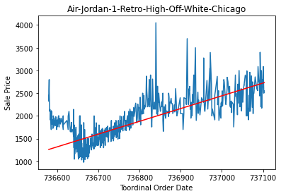

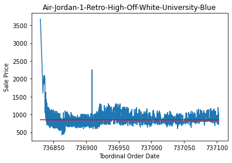

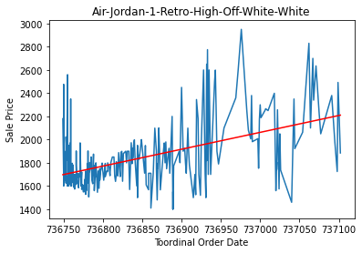

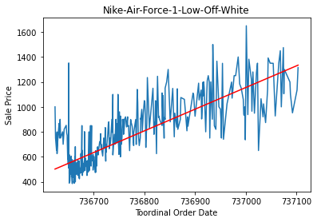

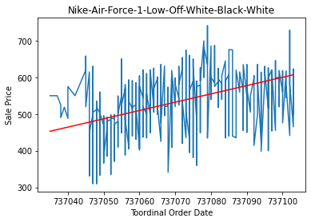

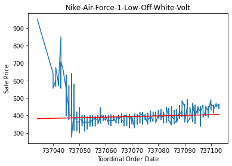

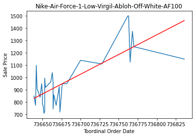

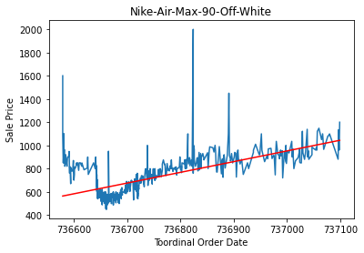

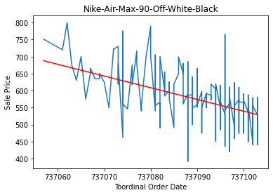

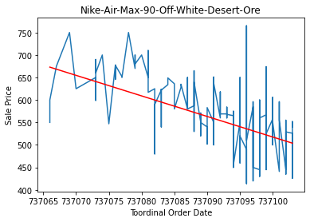

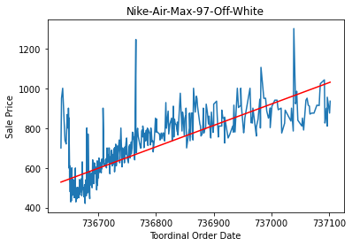

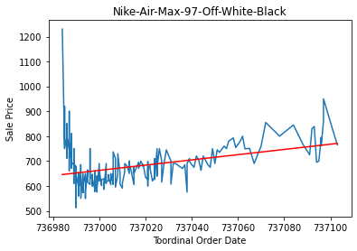

[18 more figures not shown]

```python
for title, group in offwhite:
    ind = group['Order Date'].values.reshape(-1,1)
    dep = group['Sale Price'].values.reshape(-1,1)
    lm = linear_model.LinearRegression()
    lm.fit(ind,dep)
    fig, ax = plt.subplots()
    ax.plot(ind, dep)
    ax.plot(ind, lm.predict(ind), color='red')
    ax.set_title(title)
    ax.set_xlabel("Toordinal Order Date")
    ax.set_ylabel("Sale Price")

    print(lm.fit(ind,dep).coef_, lm.fit(ind,dep).intercept_)
```

```
[[-0.74805037]] [552208.0202703]
[[-0.65883831]] [486487.57935742]
[[-0.18920051]] [140309.88599768]
[[-0.31238833]] [231167.76015664]
[[-1.31293568]] [968998.93826064]
[[-0.58109694]] [428963.56427529]
[[0.10017419]] [-73403.06839204]
[[0.02606279]] [-18823.65239304]
[[-0.27858546]] [205932.34905758]
[[-0.21913823]] [162090.76185424]
[[-0.23294145]] [172579.32959282]
[[-0.05073897]] [38190.44928015]
[[-0.15613849]] [115767.33611753]
[[-0.57242856]] [422144.49617581]
[[-1.18179029]] [871322.64097469]
[[-0.00612985]] [4782.04174243]
[[-0.77247046]] [569645.75481943]
[[-0.30451122]] [224671.89419783]
[[0.20890697]] [-153691.89078216]
[[0.15960448]] [-117172.35169692]
```

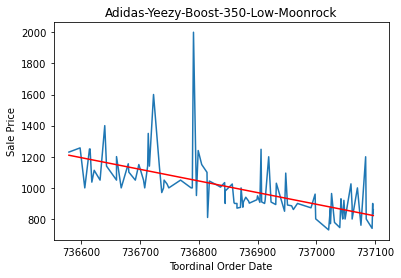

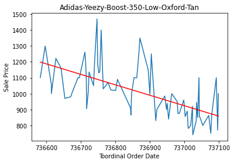

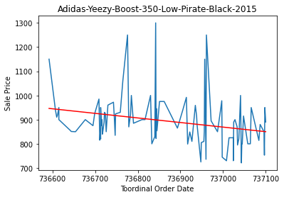

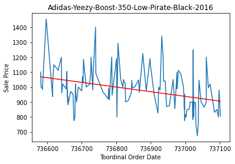

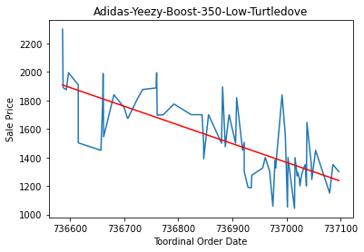

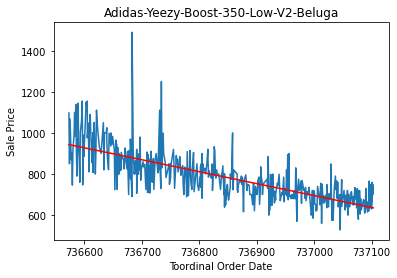

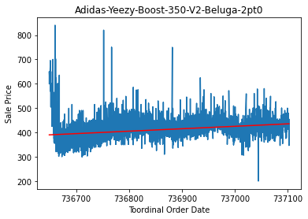

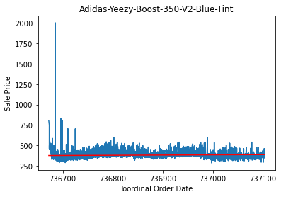

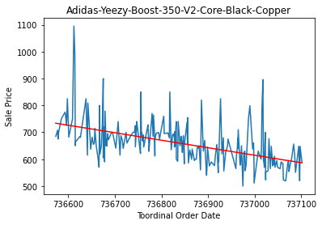

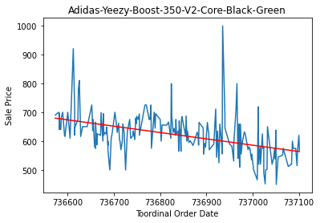

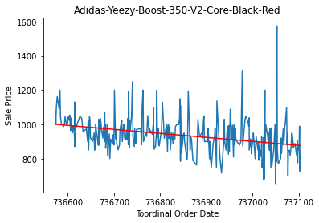

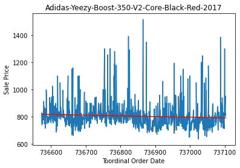

[8 more figures not shown]

```python
for title, group in yeezy:
    ind = group['Order Date'].values.reshape(-1,1)
    dep = group['Sale Price'].values.reshape(-1,1)
    lm = linear_model.LinearRegression()
    lm.fit(ind,dep)
    fig, ax = plt.subplots()
    ax.plot(ind, dep)
    ax.plot(ind, lm.predict(ind), color='red')
    ax.set_title(title)
    ax.set_xlabel("Toordinal Order Date")
    ax.set_ylabel("Sale Price")

    print(lm.fit(ind,dep).coef_, lm.fit(ind,dep).intercept_)
```